# Supplementary Information: Zoogeography

# Zoogeographic Cross-Validation

In addition to randomly-selected k-fold cross-validation, we evaluated the robustness of our models via non-random geographic cross-validation: we systematically removed all observations from a zoogeographical region, re-fit the model using all observations from outside the region, then performed a non-parametric permutation test comparing the predicted values to the observed values for that region.

## Zoonoses GAM - All Associations

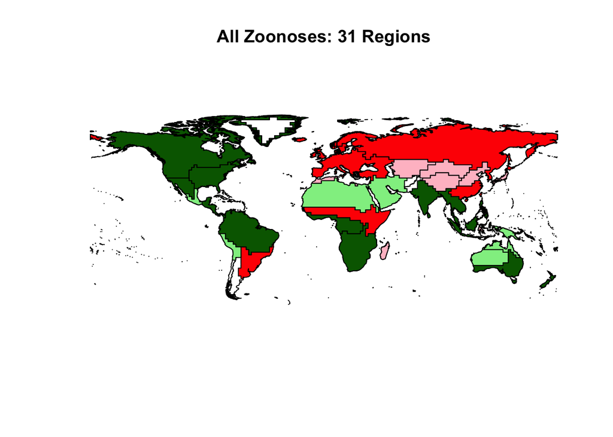

Dark green indicates unbiased regions, while dark red indicates regions with evidence of biased predictions. Light green and light red represent the same distinction, but these regions contain very few (less than ten) assigned species; blank areas were not assigned any hosts.

Biased Predictions Regions (n > 10)

| Region | Observations Fit | Observations Held Out | P-value | Mean Prediction Difference (Number of Zoonoses) |
| --- | --- | --- | --- | --- |
| Southeastern South America | 562 | 22 | 0.0039 | 0.3031 |
| Central African Band | 550 | 34 | 0.0153 | -0.4578 |
| Europe | 546 | 38 | 0.0272 | -0.3832 |
| Northern Eurussia | 548 | 36 | 0.0420 | 0.2935 |
| Southeastern China | 569 | 15 | 0.0000 | 0.4157 |

Unbiased Prediction Regions (n > 10)

| Region | Observations Fit | Observations Held Out | P-value | Mean Prediction Difference (Number of Zoonoses) |
| --- | --- | --- | --- | --- |
| Northern America | 525 | 59 | 0.6999 | -0.0443 |
| Southwestern North America | 563 | 21 | 0.9669 | -0.0049 |
| Central / Eastern North America | 562 | 22 | 0.1571 | 0.2402 |
| Southern Central America | 567 | 17 | 0.5996 | 0.0988 |
| Northern South America | 485 | 99 | 0.9949 | 0.0005 |
| West Central Africa | 551 | 33 | 0.1792 | 0.1291 |
| South Africa | 523 | 61 | 0.2029 | -0.1680 |
| India | 563 | 21 | 0.7221 | -0.1179 |
| Southeast Asia | 550 | 34 | 0.7605 | -0.0565 |
| Southern Australia | 573 | 11 | 0.2925 | -0.2760 |

## All Viruses GAM - All Associations

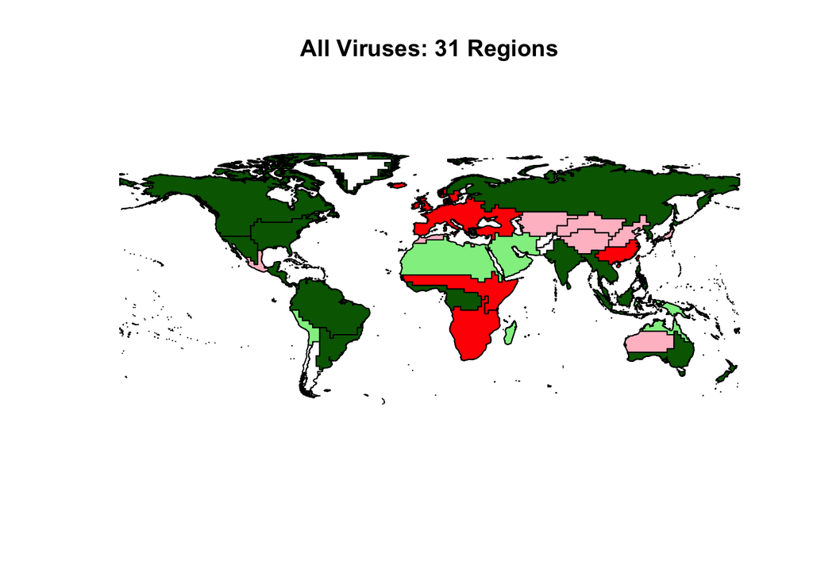

Dark green indicates unbiased regions, while dark red indicates regions with evidence of biased predictions. Light green and light red represent the same distinction, but these regions contain very few (less than ten) assigned species; blank areas were not assigned any hosts.

Biased Predictions Regions (n > 10)

| Region | Observations Fit | Observations Held Out | P-value | Mean Prediction Difference (Number of Viruses) |
| --- | --- | --- | --- | --- |
| Central African Band | 542 | 34 | 0.0269 | 0.9722 |
| Europe | 539 | 37 | 0.0004 | -1.5026 |
| South Africa | 515 | 61 | 0.0089 | 0.8337 |
| Southeastern China | 562 | 14 | 0.0008 | -1.5623 |

Unbiased Prediction Regions (n > 10)

| Region | Observations Fit | Observations Held Out | P-value | Mean Prediction Difference (Number of Viruses) |
| --- | --- | --- | --- | --- |
| Northern America | 517 | 59 | 0.8142 | -0.0527 |
| Southwestern North America | 555 | 21 | 0.8196 | 0.0851 |
| Central / Eastern North America | 554 | 22 | 0.3012 | 1.0547 |
| Southern Central America | 560 | 16 | 0.5829 | -0.4242 |
| Northern South America | 477 | 99 | 0.2172 | 0.3873 |
| Southeastern South America | 555 | 21 | 0.3828 | -0.2898 |
| West Central Africa | 545 | 31 | 0.7905 | 0.0921 |
| India | 555 | 21 | 0.2178 | 1.1181 |
| Northern Eurussia | 540 | 36 | 0.5076 | -0.3578 |
| Southeast Asia | 542 | 34 | 0.8055 | -0.1238 |
| Southern Australia | 565 | 11 | 0.4138 | 0.6794 |

## Zoonoses GAM - Strict Associations

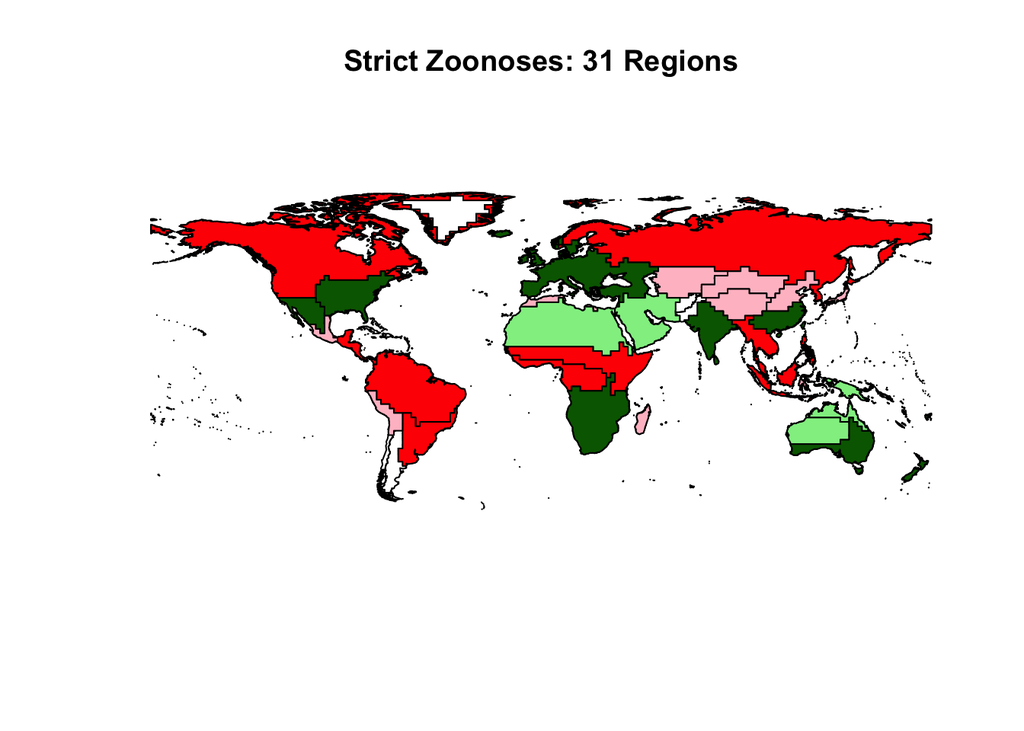

Dark green indicates unbiased regions, while dark red indicates regions with evidence of biased predictions. Light green and light red represent the same distinction, but these regions contain very few (less than ten) assigned species; blank areas were not assigned any hosts.

Biased Predictions Regions (n > 10)

| Region | Observations Fit | Observations Held Out | P-value | Mean Prediction Difference (Number of Zoonoses) |
| --- | --- | --- | --- | --- |
| Northern America | 517 | 59 | 0.0432 | -0.1885 |
| Southern Central America | 560 | 16 | 0.0000 | -0.3820 |
| Northern South America | 477 | 99 | 0.0356 | -0.2044 |
| Southeastern South America | 555 | 21 | 0.0037 | 0.6149 |
| West Central Africa | 545 | 31 | 0.0044 | 0.8319 |
| Central African Band | 542 | 34 | 0.0383 | 0.3685 |
| Northern Eurussia | 540 | 36 | 0.0182 | 0.2888 |
| Southeast Asia | 542 | 34 | 0.0074 | -0.5020 |

Unbiased Prediction Regions (n > 10)

| Region | Observations Fit | Observations Held Out | P-value | Mean Prediction Difference (Number of Zoonoses) |
| --- | --- | --- | --- | --- |
| Southwestern North America | 555 | 21 | 0.7638 | -0.0347 |
| Central / Eastern North America | 554 | 22 | 0.1234 | -0.3529 |
| Europe | 539 | 37 | 0.9486 | 0.0091 |
| South Africa | 515 | 61 | 0.7776 | -0.0244 |
| India | 555 | 21 | 0.7849 | 0.0468 |
| Southeastern China | 562 | 14 | 0.6206 | 0.0876 |
| Southern Australia | 565 | 11 | 0.7057 | -0.0988 |

## All Viruses GAM - Strict Associations

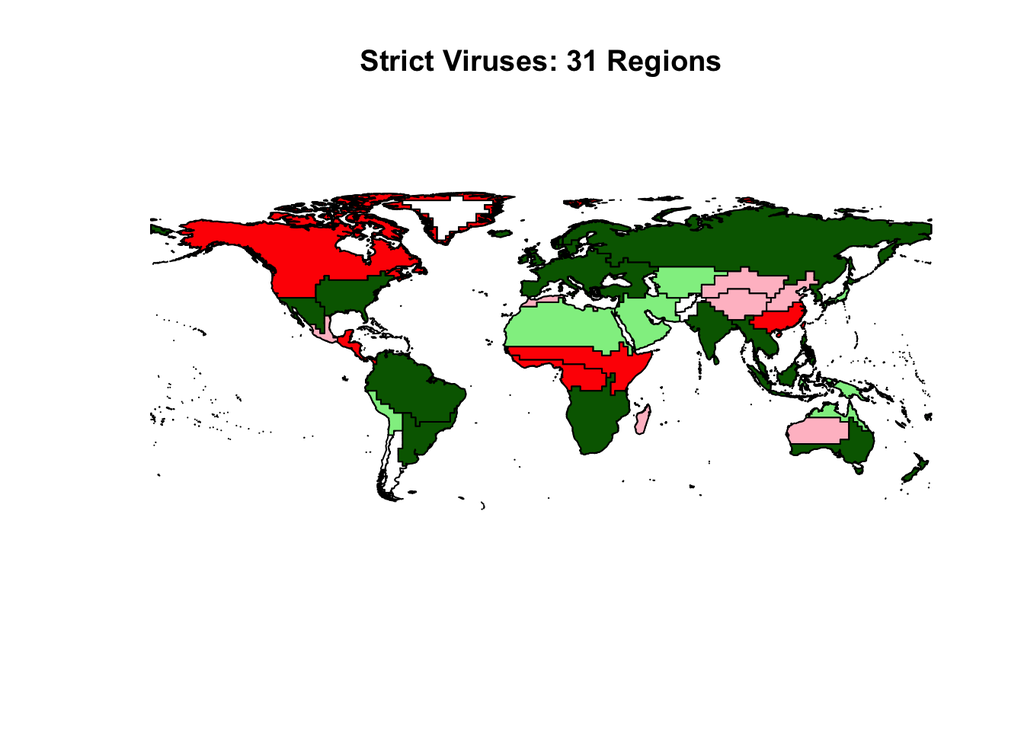

Dark green indicates unbiased regions, while dark red indicates regions with evidence of biased predictions. Light green and light red represent the same distinction, but these regions contain very few (less than ten) assigned species; blank areas were not assigned any hosts.

Biased Predictions Regions (n > 10)

| Region | Observations Fit | Observations Held Out | P-value | Mean Prediction Difference (Number of Viruses) |
| --- | --- | --- | --- | --- |
| Northern America | 516 | 59 | 0.0009 | -0.3823 |
| Southern Central America | 559 | 16 | 0.0010 | -1.0621 |
| West Central Africa | 545 | 30 | 0.0308 | 0.5590 |
| Central African Band | 541 | 34 | 0.0060 | 0.9742 |
| Southeastern China | 561 | 14 | 0.0047 | -0.5791 |

Unbiased Prediction Regions (n > 10)

| Region | Observations Fit | Observations Held Out | P-value | Mean Prediction Difference (Number of Viruses) |
| --- | --- | --- | --- | --- |
| Southwestern North America | 554 | 21 | 0.4881 | -0.1670 |
| Central / Eastern North America | 553 | 22 | 0.6871 | -0.3281 |
| Northern South America | 476 | 99 | 0.2942 | -0.2080 |
| Southeastern South America | 554 | 21 | 0.4162 | 0.3042 |
| Europe | 538 | 37 | 0.2475 | 0.3712 |
| South Africa | 514 | 61 | 0.7946 | -0.0414 |
| India | 554 | 21 | 0.5026 | 0.5320 |
| Northern Eurussia | 539 | 36 | 0.6919 | -0.1162 |
| Southeast Asia | 541 | 34 | 0.5388 | -0.1818 |
| Southern Australia | 564 | 11 | 0.3546 | 0.5891 |

# Region as Random Effect

To further investigate the relationship between zoogeographical region and our outcomes of interest, we added zoographical region as a categorical random effect to each of our best-fit GAMs. The model fit and variable relative deviance explained comparisons for each model follow:

## All Zoonoses GAM

Adding zoogeographical region as a categorical random effect to our best-fit All Zoonoses GAM does not improve the model fit, as seen in the tables below:

All Zoonoses Model Comparison

|  | Original Model | Region Model |
| --- | --- | --- |
| AIC | 1518.9011 | 1518.9012 |
| Deviance Explained | 0.3304 | 0.3304 |

All Zoonoses: Original vs. Region Model Relative Deviance Explained

| Term | Original Model Relative Deviance Explained | Region Model Relative Deviance Explained |
| --- | --- | --- |
| hDiseaseZACitesLn | 0.0774 | 0.0774 |
| hHuntedIUCN | 0.0131 | 0.0131 |
| hOrderCETARTIODACTYLA | 0.3625 | 0.3625 |
| hOrderCHIROPTERA | 0.0653 | 0.0653 |
| hOrderDIPROTODONTIA | 0.0172 | 0.0172 |
| hOrderPERAMELEMORPHIA | 0.0480 | 0.0480 |
| hOrderPERISSODACTYLA | 0.0635 | 0.0635 |
| hOrderSCANDENTIA | 0.0533 | 0.0533 |
| PdHoSa.cbCst | 0.1695 | 0.1695 |
| UrbRurPopRatioLn | 0.1301 | 0.1301 |
| zg_region | NA | 0.0000 |

## All Viruses GAM

Adding zoogeographical region as a categorical random effect to our best-fit All Viruses GAM improves the model, as seen by the decrease in AIC and the increase in deviance explained.

All Viruses Model Comparison

|  | Original Model | Region Model |
| --- | --- | --- |
| AIC | 2330.1590 | 2301.8763 |
| Deviance Explained | 0.4918 | 0.5254 |

All Viruses: Original vs. Region Model Relative Deviance Explained

| Term | Original Model Relative Deviance Explained | Region Model Relative Deviance Explained |
| --- | --- | --- |
| hDiseaseZACitesLn | 0.6481 | 0.6512 |
| hMassGramsPVR | 0.0191 | 0.0207 |
| hOrderCETARTIODACTYLA | 0.0186 | 0.0112 |
| hOrderCHIROPTERA | 0.0994 | 0.1174 |
| hOrderEULIPOTYPHLA | 0.0108 | 0.0072 |
| hOrderPERISSODACTYLA | 0.0141 | 0.0147 |
| hOrderPRIMATES | 0.0252 | 0.0196 |
| hOrderRODENTIA | 0.0479 | 0.0498 |
| LnAreaHost | 0.0158 | 0.0112 |
| S20 | 0.1009 | 0.0092 |
| zg_region | NA | 0.0879 |

## Strict Zoonoses GAM

Adding zoogeographical region as a categorical random effect to our best-fit Strict Zoonoses GAM improves the model, as seen by the decrease in AIC and the increase in deviance explained.

Strict Zoonoses Model Comparison

|  | Original Model | Region Model |
| --- | --- | --- |
| AIC | 1092.285 | 1080.4189 |
| Deviance Explained | 0.236 | 0.2858 |

Strict Zoonoses: Original vs. Region Model Relative Deviance Explained

| Term | Original Model Relative Deviance Explained | Region Model Relative Deviance Explained |
| --- | --- | --- |
| hDiseaseZACitesLn | 0.0376 | 0.0199 |
| hMassGramsPVR | 0.0112 | 0.0191 |
| hOrderCETARTIODACTYLA | 0.2802 | 0.2367 |
| hOrderDIPROTODONTIA | 0.0275 | 0.0348 |
| hOrderLAGOMORPHA | 0.0088 | 0.0049 |
| hOrderPERISSODACTYLA | 0.0500 | 0.0394 |
| hOrderPRIMATES | 0.0010 | 0.0105 |
| HumPopDensLnChg | 0.0434 | 0.0012 |
| PdHoSa.cbCst | 0.3448 | 0.2243 |
| UrbRurPopRatioChg | 0.1955 | 0.1586 |
| zg_region | NA | 0.2506 |

## Strict Viruses GAM

Adding zoogeographical region as a categorical random effect to our best-fit Strict Viruses GAM improves the model, as seen by the decrease in AIC and the increase in deviance explained.

Strict Viruses Model Comparison

|  | Original Model | Region Model |
| --- | --- | --- |
| AIC | 1730.9973 | 1703.645 |
| Deviance Explained | 0.3584 | 0.399 |

Strict Viruses: Original vs. Region Model Relative Deviance Explained

| Term | Original Model Relative Deviance Explained | Region Model Relative Deviance Explained |
| --- | --- | --- |
| hDiseaseZACitesLn | 0.5363 | 0.4892 |
| hMassGramsPVR | 0.0276 | 0.0247 |
| hOrderCHIROPTERA | 0.1223 | 0.1219 |
| hOrderCINGULATA | 0.0056 | 0.0048 |
| hOrderEULIPOTYPHLA | 0.0037 | 0.0041 |
| hOrderPERAMELEMORPHIA | 0.0036 | 0.0045 |
| hOrderPRIMATES | 0.1178 | 0.1062 |
| hOrderRODENTIA | 0.1258 | 0.1177 |
| hOrderSCANDENTIA | 0.0029 | 0.0039 |
| LnAreaHost | 0.0153 | 0.0000 |
| S20 | 0.0391 | 0.0079 |
| zg_region | NA | 0.1152 |